**POLS/CSSS 503, University of Washington, Spring 2015**

# Lab 7 - More Regression Interpretation

Carolina Johnson, Jeffrey B. Arnold

Friday May 15, 2015

As always, start the lab by loading the packages we will be using.

```r
library("car")
library("lmtest")
library("MASS")
library("dplyr")
library("ggplot2")
library("broom")
```

## More on Interpretation

Once more we’ll use data from Ross on oil, this time from the earlier 2001 paper.

```r
rossdata_url <- "http://staff.washington.edu/csjohns/503/rossoildata.csv"
rossdata_raw <- read.csv(rossdata_url, stringsAsFactors = FALSE)
rossdata <- rossdata_raw %>% select(cty_name, year, regime1,
  oil, GDPcap, oecd) %>% na.omit()
```

```r
model1 <- lm(regime1 ~ GDPcap + oil + oecd + year, data = rossdata)
summary(model1)
```

```
##
## Call:
## lm(formula = regime1 ~ GDPcap + oil + oecd + year, data = rossdata)
##
## Residuals:
##     Min      1Q  Median      3Q     Max
## -7.8284 -2.5065 -0.2086  2.2014  8.0464
##
## Coefficients:
##               Estimate Std. Error t value Pr(>|t|)
## (Intercept) -1.736e+02  1.664e+01 -10.433  < 2e-16 ***
## GDPcap       6.177e-05  1.823e-05   3.387 0.000716 ***
## oil         -8.262e-02  5.022e-03 -16.450  < 2e-16 ***
## oecd         4.116e+00  1.928e-01  21.346  < 2e-16 ***
## year         9.008e-02  8.413e-03  10.708  < 2e-16 ***
## ---
## Signif. codes:  0 '***' 0.001 '**' 0.01 '*' 0.05 '.' 0.1 ' ' 1
##
## Residual standard error: 2.932 on 2589 degrees of freedom
## Multiple R-squared:  0.4285, Adjusted R-squared:  0.4276
## F-statistic: 485.2 on 4 and 2589 DF,  p-value: < 2.2e-16
```

Now predict the expected value of regime type vs. oil:

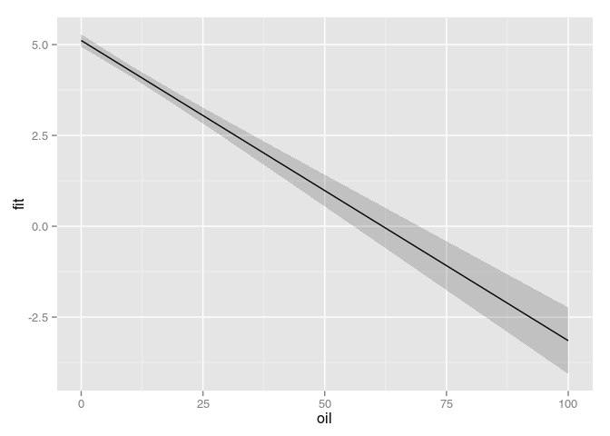

```r
pred1_df <- data.frame(oil = seq(0, 100, by = 10), GDPcap = mean(rossdata$GDPcap),
  oecd = 0, year = median(rossdata$year))
pred1 <- predict(model1, newdata = pred1_df, interval = "confidence")

ggplot(bind_cols(pred1_df, as.data.frame(pred1)), aes(x = oil,
  y = fit, ymin = lwr, ymax = upr)) + geom_ribbon(alpha = 0.2) +
  geom_line()
```

This is easiest to plot with `augment` instead

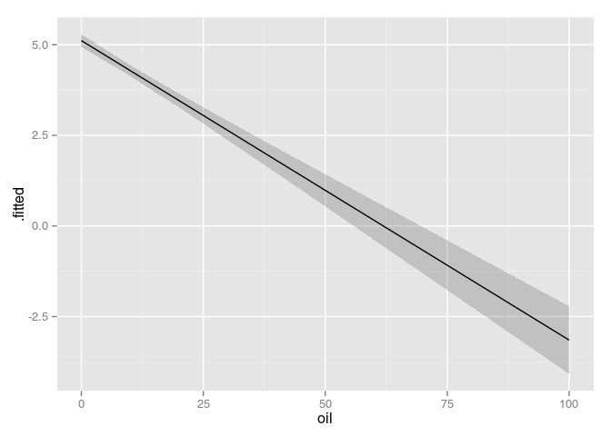

```r
pred1_aug <- augment(model1, newdata = pred1_df)
ggplot(pred1_aug, aes(x = oil, y = .fitted, ymin = .fitted +
  2 * .se.fit, ymax = .fitted - 2 * .se.fit)) + geom_ribbon(alpha = 0.2) +
  geom_line()
```

**Challenge:** Do this with both OECD and non-OECD countries. Before plotting, how will these differ?

**Answer:**

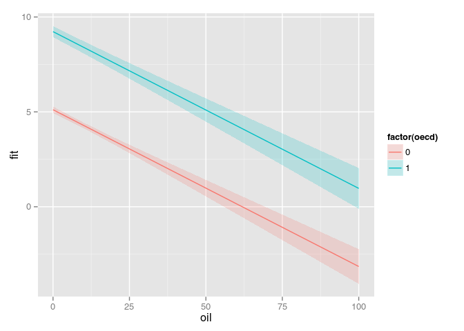

```r
pred2_df <- expand.grid(oil = seq(0, 100, by = 10), GDPcap = mean(rossdata$GDPcap),
  oecd = c(0, 1), year = median(rossdata$year))
pred2 <- predict(model1, newdata = pred2_df, interval = "confidence")
ggplot(bind_cols(pred2_df, as.data.frame(pred2)), aes(x = oil,
  y = fit, ymin = lwr, ymax = upr, colour = factor(oecd), fill = factor(oecd))) +
  geom_ribbon(alpha = 0.2, colour = NA) + geom_line()
```

Let’s plot with `augment` instead

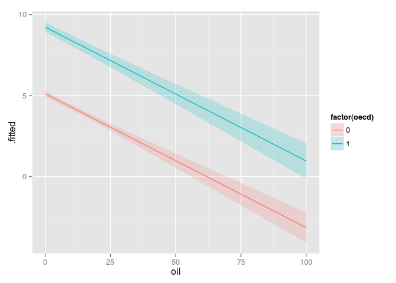

```r
pred1_aug <- augment(model1, newdata = pred2_df)
ggplot(pred1_aug, aes(x = oil, y = .fitted, ymin = .fitted +
  2 * .se.fit, ymax = .fitted - 2 * .se.fit, fill = factor(oecd),
  colour = factor(oecd))) + geom_ribbon(alpha = 0.2, colour = NA) +
  geom_line()
```

**Challenge:** Does it make sense to plot `oil` from 0 to 100? Check the range of `oil`.

**Answer:** Surprisingly, not that bad.

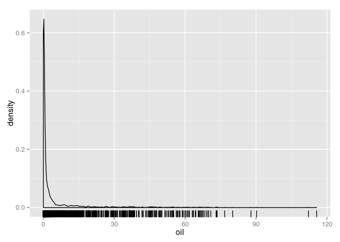

```r
ggplot(rossdata, aes(x = oil)) + geom_density() + geom_rug()
```

**Challenge:** Interact `oil` with `oecd` and plot. What will the lines look like?

```r
model2 <- lm(regime1 ~ GDPcap + oil * oecd + year, data = rossdata)
summary(model2)
```

```
##
## Call:
## lm(formula = regime1 ~ GDPcap + oil * oecd + year, data = rossdata)
##
## Residuals:
##     Min      1Q  Median      3Q     Max
## -7.7411 -2.5075 -0.1755  2.2446  8.0701
##
## Coefficients:
##               Estimate Std. Error t value Pr(>|t|)
## (Intercept) -1.732e+02  1.663e+01 -10.410  < 2e-16 ***
## GDPcap       5.931e-05  1.826e-05   3.248  0.00118 **
## oil         -8.344e-02  5.035e-03 -16.571  < 2e-16 ***
## oecd         4.005e+00  2.003e-01  19.998  < 2e-16 ***
## year         8.985e-02  8.408e-03  10.686  < 2e-16 ***
## oil:oecd     8.863e-02  4.340e-02   2.042  0.04124 *
## ---
## Signif. codes:  0 '***' 0.001 '**' 0.01 '*' 0.05 '.' 0.1 ' ' 1
##
## Residual standard error: 2.93 on 2588 degrees of freedom
## Multiple R-squared:  0.4294, Adjusted R-squared:  0.4283
## F-statistic: 389.5 on 5 and 2588 DF,  p-value: < 2.2e-16
```

Now consider interact `oil` with `year`. How would you plot two continuous variables?

```r
model3 <- lm(regime1 ~ GDPcap + oecd + oil * year, data = rossdata)
summary(model3)
```

```
##
## Call:
## lm(formula = regime1 ~ GDPcap + oecd + oil * year, data = rossdata)
##
## Residuals:
##     Min      1Q  Median      3Q     Max
## -7.7659 -2.4662 -0.2211  2.2458  7.5283
##
## Coefficients:
##               Estimate Std. Error t value Pr(>|t|)
## (Intercept) -1.900e+02  1.721e+01 -11.039  < 2e-16 ***
## GDPcap       6.228e-05  1.819e-05   3.424 0.000628 ***
## oecd         4.108e+00  1.924e-01  21.351  < 2e-16 ***
## oil          4.400e+00  1.242e+00   3.543 0.000403 ***
## year         9.835e-02  8.700e-03  11.304  < 2e-16 ***
## oil:year    -2.263e-03  6.269e-04  -3.609 0.000313 ***
## ---
## Signif. codes:  0 '***' 0.001 '**' 0.01 '*' 0.05 '.' 0.1 ' ' 1
##
## Residual standard error: 2.925 on 2588 degrees of freedom
## Multiple R-squared:  0.4313, Adjusted R-squared:  0.4302
## F-statistic: 392.6 on 5 and 2588 DF,  p-value: < 2.2e-16
```

In order to interpret the interaction term graphically, we need to pick one variable to treat as continuous — the x-axis — and another for which we will choose specific values. Use `oil` as the x-axis, and some values of `year` at which to evaluate it. For `year` we could use the min, max, and median.

```r
pred3_newdata <- expand.grid(oecd = 0, GDPcap = mean(rossdata$GDPcap),
  year = c(1966, 1981, 1997), oil = seq(0, 100, by = 10))
pred3 <- augment(model3, newdata = pred3_newdata)
```

Now, let’s plot it,

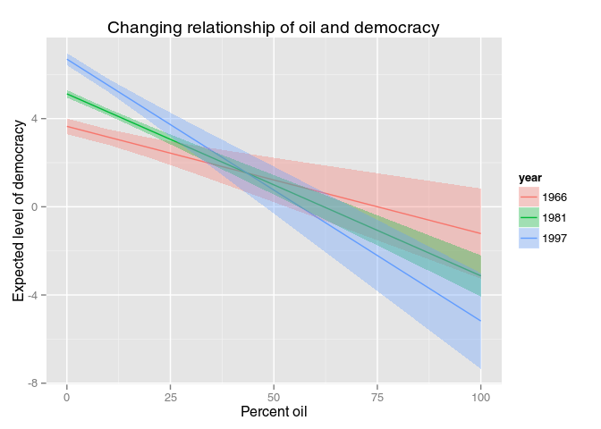

```r
ggplot(pred3, aes(x = oil, y = .fitted, ymin = .fitted - 2 *
  .se.fit, ymax = .fitted + 2 * .se.fit, )) + geom_line(aes(colour = factor(year))) +
  geom_ribbon(aes(fill = factor(year)), alpha = 1/3) + scale_colour_discrete("year") +
  scale_fill_discrete("year") + labs(x = "Percent oil", y = "Expected level of democracy",
  title = "Changing relationship of oil and democracy")
```

**Challenge** Interact `GDPpc` with oil and visualize the interactions.

## First Differences

```r
year_seq <- seq(min(rossdata$year), max(rossdata$year), by = 1)
oil_lo <- mean(rossdata$GDPcap)
oil_hi <- mean(rossdata$GDPcap) + sd(rossdata$GDPcap)
pred3_oil_lo <- predict(model3, newdata = data.frame(year = year_seq,
  GDPcap = mean(rossdata$GDPcap), oil = oil_lo, oecd = 0),
  interval = "confidence")

pred3_oil_hi <- predict(model3, newdata = data.frame(year = year_seq,
  GDPcap = mean(rossdata$GDPcap), oil = oil_hi, oecd = 0),
  interval = "confidence")
```

The first difference is calculated. Note that there are no standard error associated with these differences.

```r
pred3_diff <- data.frame(year = year_seq, diff = pred3_oil_hi[,
  "fit"] - pred3_oil_lo[, "fit"])
head(pred3_diff)
```

```
##   year      diff
## 1 1966 -259.0802
## 2 1967 -271.1370
## 3 1968 -283.1938
## 4 1969 -295.2507
## 5 1970 -307.3075
## 6 1971 -319.3643
```

We could plot these differences over time.

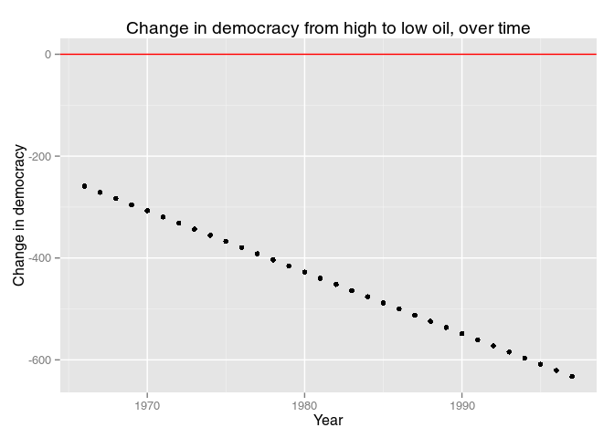

```r
ggplot(pred3_diff, aes(x = year, y = diff)) + geom_point() +
  geom_hline(yintercept = 0, colour = "red") + labs(x = "Year",
  y = "Change in democracy", title = "Change in democracy from high to low oil, over time")
```

**Challenge:**

- What does this plot tell us about the relationship between oil and democracy over time?
- What does this provide that the previous plot does not?
- How would you you calculate confidence intervals around these estimates?

# Transformations

What if we suspect the effect of oil is non-linear?

Specifying a model:

```r
model4 <- lm(regime1 ~ GDPcap + oil + I(oil^2) + oecd, data = rossdata)
summary(model4)
```

```
##
## Call:
## lm(formula = regime1 ~ GDPcap + oil + I(oil^2) + oecd, data = rossdata)
##
## Residuals:
##     Min      1Q  Median      3Q     Max
## -7.6194 -2.7171 -0.1169  2.1843  7.8092
##
## Coefficients:
##               Estimate Std. Error t value Pr(>|t|)
## (Intercept)  4.593e+00  8.301e-02  55.329   <2e-16 ***
## GDPcap       1.878e-04  1.425e-05  13.180   <2e-16 ***
## oil         -1.084e-01  1.213e-02  -8.935   <2e-16 ***
## I(oil^2)     2.691e-04  1.941e-04   1.387    0.166
## oecd         3.171e+00  1.759e-01  18.034   <2e-16 ***
## ---
## Signif. codes:  0 '***' 0.001 '**' 0.01 '*' 0.05 '.' 0.1 ' ' 1
##
## Residual standard error: 2.995 on 2589 degrees of freedom
## Multiple R-squared:  0.4036, Adjusted R-squared:  0.4027
## F-statistic:   438 on 4 and 2589 DF,  p-value: < 2.2e-16
```

```r
oil_hyp <- seq(from = 0.01, to = 100, by = 10)
pred4 <- predict(model4, newdata = data.frame(oil = oil_hyp,
  GDPcap = mean(rossdata$GDPcap), oecd = 0), interval = "confidence") %>%
  as.data.frame()
pred4$oil <- oil_hyp
```

Plotting the resulting expectations:

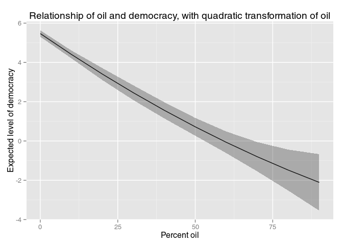

```r
ggplot(pred4, aes(x = oil)) + geom_line(aes(y = fit)) + geom_ribbon(aes(ymax = upr,
  ymin = lwr), alpha = 1/3) + labs(x = "Percent oil", y = "Expected level of democracy",
  title = "Relationship of oil and democracy, with quadratic transformation of oil")
```

**Challenge:** Transform GDP per capita by log.

**Answer:** Specifying a model:

```r
model_logGDP <- lm(regime1 ~ log(GDPcap) + oil + oecd, data = rossdata)
summary(model_logGDP)
```

```
##
## Call:
## lm(formula = regime1 ~ log(GDPcap) + oil + oecd, data = rossdata)
##
## Residuals:
##    Min     1Q Median     3Q    Max
## -7.169 -2.125 -0.077  2.010  7.539
##
## Coefficients:
##             Estimate Std. Error t value Pr(>|t|)
## (Intercept) -5.46656    0.42426  -12.88   <2e-16 ***
## log(GDPcap)  1.43853    0.05761   24.97   <2e-16 ***
## oil         -0.11005    0.00470  -23.42   <2e-16 ***
## oecd         2.22692    0.15951   13.96   <2e-16 ***
## ---
## Signif. codes:  0 '***' 0.001 '**' 0.01 '*' 0.05 '.' 0.1 ' ' 1
##
## Residual standard error: 2.778 on 2590 degrees of freedom
## Multiple R-squared:  0.4868, Adjusted R-squared:  0.4862
## F-statistic: 818.8 on 3 and 2590 DF,  p-value: < 2.2e-16
```

```r
gdp_hyp <- seq(from = min(rossdata$GDPcap), to = max(rossdata$GDPcap),
  length.out = 50)
pred4 <- predict(model_logGDP, newdata = data.frame(oil = median(oil_hyp),
  GDPcap = gdp_hyp, oecd = 0), interval = "confidence") %>%
  as.data.frame()
pred4$gdp <- gdp_hyp
```

Why was median used there?

Plotting the resulting expectations:

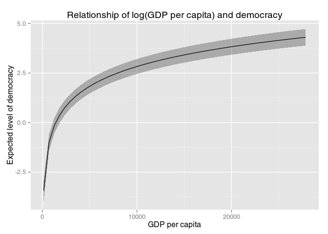

```r
ggplot(pred4, aes(x = gdp)) + geom_line(aes(y = fit)) + geom_ribbon(aes(ymax = upr,
  ymin = lwr), alpha = 1/3) + labs(x = "GDP per capita", y = "Expected level of democracy",
  title = "Relationship of log(GDP per capita) and democracy")
```

**Challenge:** Transform oil by log. What happens? How would you solve it?

Log of 0 is undefined. This is often handled by adding and arbitrary small value to 0’s. In this case we’ll add 0.001. There are better ways to deal with this, but for now…

```r
model_logoil <- lm(regime1 ~ GDPcap + log(oil_mod) + oecd, data = mutate(rossdata,
  oil_mod = log(oil + 0.001)))
summary(model_logoil)
```

```
##
## Call:
## lm(formula = regime1 ~ GDPcap + log(oil_mod) + oecd, data = mutate(rossdata,
##     oil_mod = log(oil + 0.001)))
##
## Residuals:
##      Min       1Q   Median       3Q      Max
## -10.6337  -2.4525  -0.7552   1.2146   6.5659
##
## Coefficients:
##                Estimate Std. Error t value Pr(>|t|)
## (Intercept)   3.850e+00  1.434e-01  26.847  < 2e-16 ***
## GDPcap        2.708e-05  2.419e-05   1.119    0.263
## log(oil_mod) -7.896e-01  1.018e-01  -7.755 2.42e-14 ***
## oecd          5.420e+00  3.310e-01  16.373  < 2e-16 ***
## ---
## Signif. codes:  0 '***' 0.001 '**' 0.01 '*' 0.05 '.' 0.1 ' ' 1
##
## Residual standard error: 2.976 on 887 degrees of freedom
##   (1703 observations deleted due to missingness)
## Multiple R-squared:  0.4523, Adjusted R-squared:  0.4504
## F-statistic: 244.1 on 3 and 887 DF,  p-value: < 2.2e-16
```

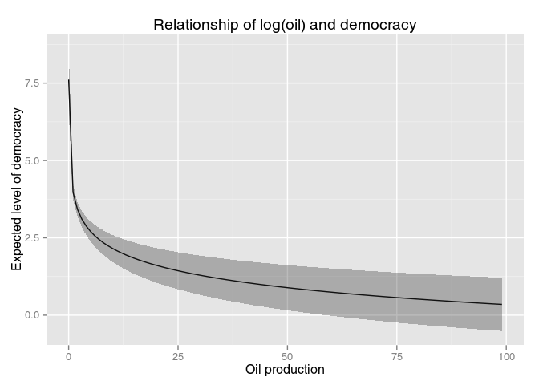

```r
pred_logoil <- as.data.frame(predict(model_logoil, newdata = data.frame(oil_mod = seq(from = 0.01,
  to = 100, by = 1), GDPcap = mean(rossdata$GDPcap), oecd = 0),
  interval = "confidence"))
pred_logoil$oil <- seq(from = 0.01, to = 100, by = 1)

ggplot(pred_logoil, aes(x = oil)) + geom_line(aes(y = fit)) +
  geom_ribbon(aes(ymax = upr, ymin = lwr), alpha = 1/3) + labs(x = "Oil production",
  y = "Expected level of democracy", title = "Relationship of log(oil) and democracy")
```

# Post-estimation Diagnostics

Recall the default model,

```r
model1
```

```
##
## Call:
## lm(formula = regime1 ~ GDPcap + oil + oecd + year, data = rossdata)
##
## Coefficients:
## (Intercept)       GDPcap          oil         oecd         year
##  -1.736e+02    6.177e-05   -8.262e-02    4.116e+00    9.008e-02
```

We can use the functions `residuals` and `predict` to extract residuals and fitted values from an `lm` object:

```r
residuals(model1)
fitted(model1)
```

```r
model1_aug <- augment(model1)
```

We can plot the fitted values vs. the outcome variable to look for nonlinearity,

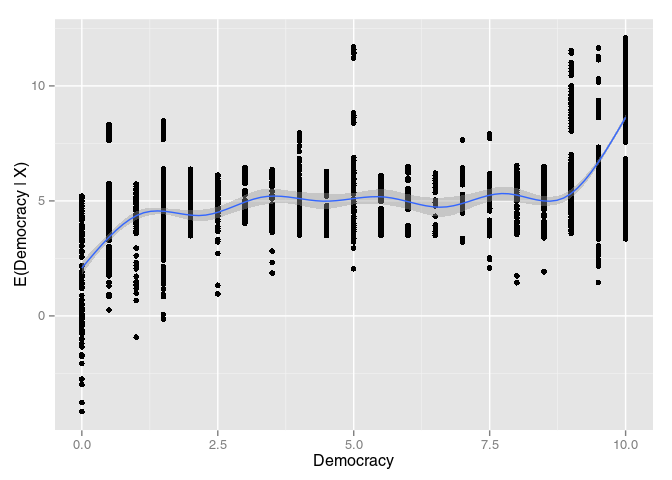

```r
ggplot(model1_aug, aes(x = regime1, y = .fitted)) + geom_point() +
  geom_smooth() + ylab("E(Democracy | X)") + xlab("Democracy")
```

or the residuals vs. the fitted values to look for heteroskedasticity

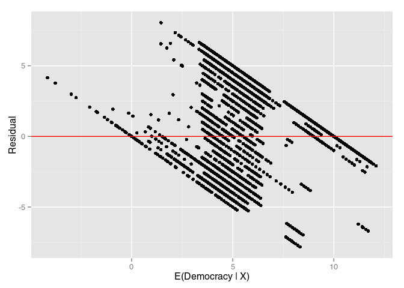

```r
ggplot(model1_aug, aes(x = .fitted, y = .resid)) + geom_point() +
  geom_hline(yintercept = 0, colour = "red") + ylab("Residual") +
  xlab("E(Democracy | X)")
```

**Challenge:** What accounts for the unusual patterns? *hint:* What values can Democracy take?

It is obvious in this case, but plotting the sqrt of the absolute value of the errors can make it more clear

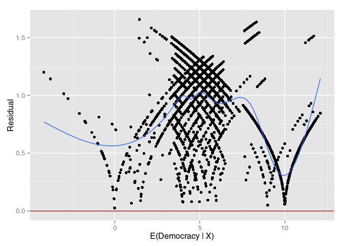

```r
ggplot(model1_aug, aes(x = .fitted, y = sqrt(abs(.std.resid)))) +
  geom_point() + geom_hline(yintercept = 0, colour = "red") +
  geom_smooth(se = FALSE) + ylab("Residual") + xlab("E(Democracy | X)")
```

**Challenge:** Plot residuals against each independent variable, and the fitted values. Is there evidence of heteroskedasticity or nonlinearity?

**Answer:**

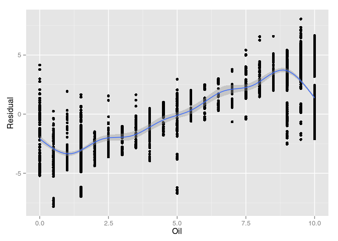

```r
ggplot(model1_aug, aes(x = regime1, y = .resid)) + geom_point() +
  geom_smooth() + ylab("Residual") + xlab("Oil")
```

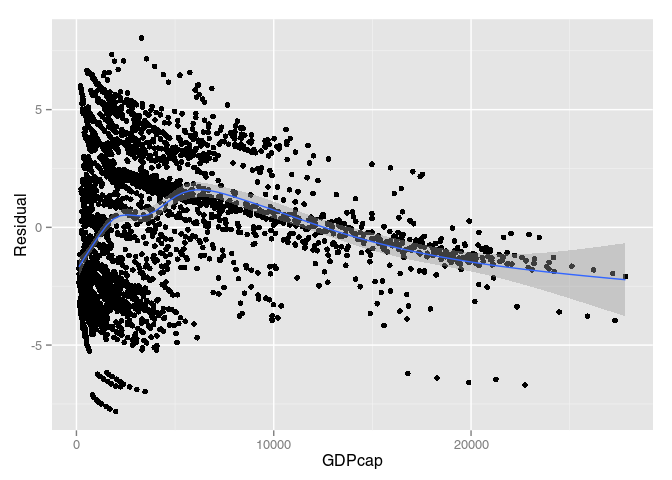

```r
ggplot(model1_aug, aes(x = GDPcap, y = .resid)) + geom_point() +
  geom_smooth() + ylab("Residual") + xlab("GDPcap")
```

**Challenge:** Compare residual plot for model with `log(GDPcap)`. How have the residual plots changed?

**Answer:**

```r
# model with logged GDP per capita
summary(model_logGDP)
```

```
##
## Call:
## lm(formula = regime1 ~ log(GDPcap) + oil + oecd, data = rossdata)
##
## Residuals:
##    Min     1Q Median     3Q    Max
## -7.169 -2.125 -0.077  2.010  7.539
##
## Coefficients:
##             Estimate Std. Error t value Pr(>|t|)
## (Intercept) -5.46656    0.42426  -12.88   <2e-16 ***
## log(GDPcap)  1.43853    0.05761   24.97   <2e-16 ***
## oil         -0.11005    0.00470  -23.42   <2e-16 ***
## oecd         2.22692    0.15951   13.96   <2e-16 ***
## ---
## Signif. codes:  0 '***' 0.001 '**' 0.01 '*' 0.05 '.' 0.1 ' ' 1
##
## Residual standard error: 2.778 on 2590 degrees of freedom
## Multiple R-squared:  0.4868, Adjusted R-squared:  0.4862
## F-statistic: 818.8 on 3 and 2590 DF,  p-value: < 2.2e-16
```

```r
logGDP_aug <- augment(model_logGDP)

# look at how the augment dataframe updates to the
# transformed variables:
head(logGDP_aug)
```

```
##   .rownames regime1 log.GDPcap.         oil oecd  .fitted    .se.fit
## 1        48     1.5    7.440232 35.60206200    0 1.318336 0.15262838
## 2        49     5.0    7.440232 26.51153200    0 2.318776 0.11508216
## 3        86     5.0    7.722483  0.23792800    0 5.616292 0.07275067
## 4        87     8.0    7.638494  0.06946399    0 5.514012 0.07152078
## 5        92     1.5    9.709267 65.93863000    0 1.243784 0.27989124
## 6        93     1.5    9.687519 64.25789000    0 1.397469 0.27287186
##       .resid         .hat   .sigma      .cooksd  .std.resid
## 1  0.1816644 0.0030183605 2.778646 3.246211e-06  0.06549021
## 2  2.6812241 0.0017159972 2.778148 4.009730e-04  0.96595374
## 3 -0.6162924 0.0006857639 2.778622 8.448597e-06 -0.22191468
## 4  2.4859883 0.0006627734 2.778218 1.328555e-04  0.89514485
## 5  0.2562156 0.0101503065 2.778644 2.202888e-05  0.09269819
## 6  0.1025306 0.0096475725 2.778648 3.349548e-06  0.03708591
```

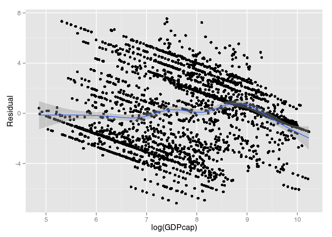

```r
ggplot(logGDP_aug, aes(x = log.GDPcap., y = .resid)) + geom_point() +
  geom_smooth() + ylab("Residual") + xlab("log(GDPcap)")
```

What about the normality of errors?

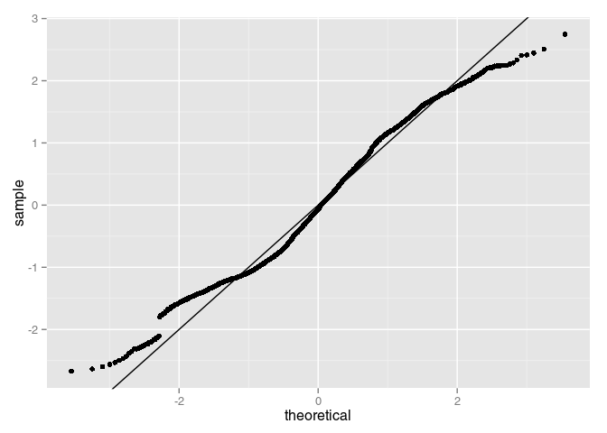

```r
ggplot(model1_aug, aes(sample = .std.resid)) + stat_qq() + geom_abline(slope = 1)
```

For more advanced residual plots see **car** functions:

- `avPlots`: added variable plot
- `ceresPlots`, `crPlots`: Component + residual (partial residual) plots
- `residualPlots`

Also try using `plot` on an `lm` object:

```r
plot(model1)
```

Alternatively, base graphics can be appropriate for quickly generating plots of residuals:

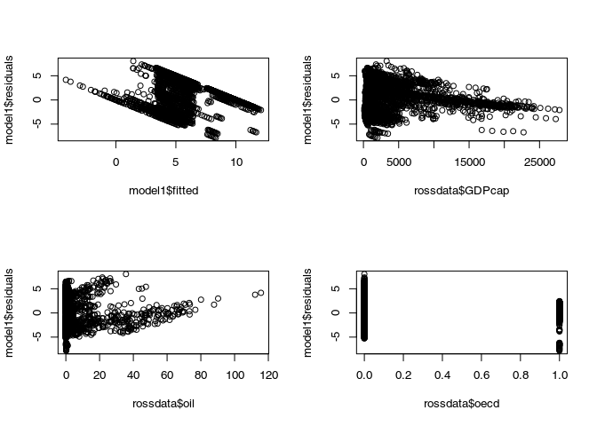

```r
par(mfrow = c(2, 2))
plot(model1$fitted, model1$residuals)  #what is this plot showing?
plot(rossdata$GDPcap, model1$residuals)  #what is this plot showing?
plot(rossdata$oil, model1$residuals)
plot(rossdata$oecd, model1$residuals)
```

```r
par(mfrow = c(1, 1))
```

## Robust standard errors

We can calculate heteroskedasticity consistent (robust, White) standard errors using the **car** function `hccm`:

The robust standard errors for the coefficients of `model1` are:

```r
sqrt(diag(hccm(model1)))
```

```
##  (Intercept)       GDPcap          oil         oecd         year
## 1.744310e+01 1.710027e-05 4.213601e-03 1.848413e-01 8.813878e-03
```

Are they different than the classical standard errors of those in `model1`?

To use the robust standard errors in a significance test supply the robust variance-covariance matrix to the `coeftest` function from the **lmtest** package:

```r
coeftest(model1, hccm(model1))
```

```
##
## t test of coefficients:
##
##                Estimate  Std. Error  t value  Pr(>|t|)
## (Intercept) -1.7363e+02  1.7443e+01  -9.9542 < 2.2e-16 ***
## GDPcap       6.1766e-05  1.7100e-05   3.6120 0.0003096 ***
## oil         -8.2617e-02  4.2136e-03 -19.6073 < 2.2e-16 ***
## oecd         4.1160e+00  1.8484e-01  22.2676 < 2.2e-16 ***
## year         9.0084e-02  8.8139e-03  10.2207 < 2.2e-16 ***
## ---
## Signif. codes:  0 '***' 0.001 '**' 0.01 '*' 0.05 '.' 0.1 ' ' 1
```

# Using simulation to compute expected values and confidence intervals:

(The answer to confidence intervals on first differences) We’re going to load the dataset on occupational prestige used by Fox in Chapter 5. Note: you can view the codebook here: http://socserv.socsci.mcmaster.ca/jfox/Books/Applied-Regression-2E/datasets/Prestige.pdf

```r
jobs <- read.table("http://socserv.socsci.mcmaster.ca/jfox/Books/Applied-Regression-2E/datasets/Prestige.txt")
summary(jobs)
```

```
##    education          income          women           prestige
##  Min.   : 6.380   Min.   :  611   Min.   : 0.000   Min.   :14.80
##  1st Qu.: 8.445   1st Qu.: 4106   1st Qu.: 3.592   1st Qu.:35.23
##  Median :10.540   Median : 5930   Median :13.600   Median :43.60
##  Mean   :10.738   Mean   : 6798   Mean   :28.979   Mean   :46.83
##  3rd Qu.:12.648   3rd Qu.: 8187   3rd Qu.:52.203   3rd Qu.:59.27
##  Max.   :15.970   Max.   :25879   Max.   :97.510   Max.   :87.20
##      census       type
##  Min.   :1113   bc  :44
##  1st Qu.:3120   prof:31
##  Median :5135   wc  :23
##  Mean   :5402   NA's: 4
##  3rd Qu.:8312
##  Max.   :9517
```

```r
foxmodel <- lm(prestige ~ education + income + women, data = jobs)
summary(foxmodel)
```

```
##
## Call:
## lm(formula = prestige ~ education + income + women, data = jobs)
##
## Residuals:
##      Min       1Q   Median       3Q      Max
## -19.8246  -5.3332  -0.1364   5.1587  17.5045
##
## Coefficients:
##               Estimate Std. Error t value Pr(>|t|)
## (Intercept) -6.7943342  3.2390886  -2.098   0.0385 *
## education    4.1866373  0.3887013  10.771  < 2e-16 ***
## income       0.0013136  0.0002778   4.729 7.58e-06 ***
## women       -0.0089052  0.0304071  -0.293   0.7702
## ---
## Signif. codes:  0 '***' 0.001 '**' 0.01 '*' 0.05 '.' 0.1 ' ' 1
##
## Residual standard error: 7.846 on 98 degrees of freedom
## Multiple R-squared:  0.7982, Adjusted R-squared:  0.792
## F-statistic: 129.2 on 3 and 98 DF,  p-value: < 2.2e-16
```

Now let’s extract the coefficients vector and the variance-covariance matrix:

```r
pe <- coef(foxmodel)
vc <- vcov(foxmodel)

pe  #look at them
```

```
##  (Intercept)    education       income        women
## -6.794334203  4.186637275  0.001313560 -0.008905157
```

```r
vc
```

```
##               (Intercept)     education        income         women
## (Intercept) 10.4916952589 -0.9787550408  1.151261e-04 -5.548945e-03
## education   -0.9787550408  0.1510886706 -7.290930e-05 -5.107514e-03
## income       0.0001151261 -0.0000729093  7.716239e-08  4.942693e-06
## women       -0.0055489446 -0.0051075141  4.942693e-06  9.245892e-04
```

Suppose we want to calculate the predicted value of prestige for a job that requires 10 years of education, pays #$10,000 (in 1971 dollars), and is 50% female.

The long-winded way of doing it is:

```r
predictedvalue <- pe[1] + 10 * pe[2] + 10000 * pe[3] + 50 * pe[4]

predictedvalue
```

```
## (Intercept)
##    47.76238
```

Remember: This is just a way of manually doing what `predict()` does. A faster way of doing it uses matrix multiplication:

```r
predictedvalue <- c(1, 10, 10000, 50) %*% pe
predictedvalue
```

```
##          [,1]
## [1,] 47.76238
```

Let’s now try to model the uncertainty around this estimate. We can do this by taking random draws from the #distribution of possible beta values that our model has estimated.

```r
library(MASS)
simbetas <- mvrnorm(1000, pe, vc)  # this gives us 1000 estimates of the coefficient estimates
head(simbetas)  # look at it
```

```
##      (Intercept) education       income        women
## [1,]   -7.631284  4.516390 0.0011517328 -0.054344816
## [2,]   -1.505474  4.053175 0.0011332223 -0.070489993
## [3,]  -11.124032  4.927227 0.0007272636 -0.038785661
## [4,]   -2.770193  3.665343 0.0013609293  0.003483023
## [5,]   -7.935638  4.640948 0.0010711982 -0.015643749
## [6,]   -1.426559  3.554148 0.0017483996 -0.005404129
```

Examine the uncertainty around each coefficient (this is using base graphics for quick and dirty data exploration):

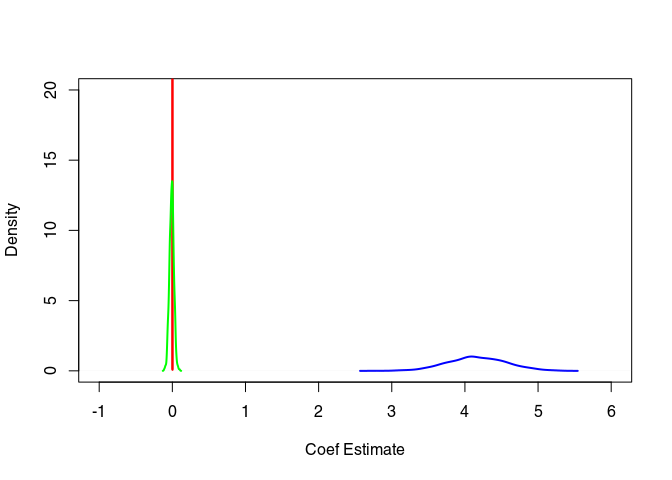

```r
plot(density(simbetas[, 2]), col = "blue", lwd = 2, xlim = c(-1,
  6), ylim = c(0, 20), main = "", xlab = "Coef Estimate")  #initiating a plot with the first density
lines(density(simbetas[, 3]), col = "red", lwd = 2)  # adding next coef
lines(density(simbetas[, 4]), col = "green", lwd = 2)  # adding last coef
```

What’s going on with the red one? Examine coefficient for income more closely (it’s still normal):

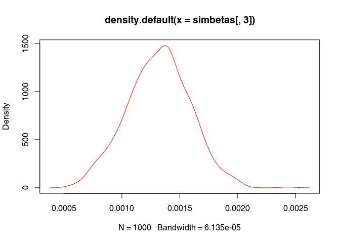

```r
plot(density(simbetas[, 3]), col = "red")
```

Now let’s calculate the predicted values of prestige for each of the 1000 possible coefficient estimates. We can do this most efficiently using matrix algebra:

```r
xhyp <- c(1, 10, 10000, 50)  # define our scenario: vector of hypothetical x values
predictions <- simbetas %*% xhyp
head(predictions)  # look at it
```

```
##          [,1]
## [1,] 46.33270
## [2,] 46.83399
## [3,] 43.48159
## [4,] 47.66669
## [5,] 48.40363
## [6,] 51.32871
```

Now let’s look at the distribution of predicted values:

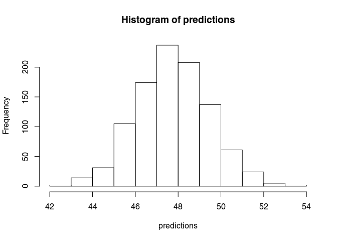

```r
hist(predictions)
```

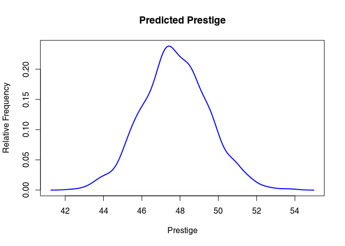

```r
plot(density(predictions), main = "Predicted Prestige", lwd = 2,
  col = "blue", xlab = "Prestige", ylab = "Relative Frequency")
```

We can calculate the mean of this distribution, and the lower and upper 95% confidence intervals like this:

```r
EV <- mean(predictions)
lowerCI <- quantile(predictions, probs = 0.025)
upperCI <- quantile(predictions, probs = 0.975)
```

Compare the `EV` to the `predictedvalue` above:

```r
EV
```

```
## [1] 47.75398
```

```r
predictedvalue  # you'll see that it's roughly the same, but not exactly.  Why not?
```

```
##          [,1]
## [1,] 47.76238
```

You can also compare these estimates to those obtained using the function predict().

```r
predict.lm(foxmodel, newdata = list(education = 10, income = 10000,
  women = 50), interval = "confidence")
```

```
##        fit      lwr      upr
## 1 47.76238 44.29432 51.23045
```

```r
EV
```

```
## [1] 47.75398
```

```r
lowerCI
```

```
##     2.5%
## 44.27828
```

```r
upperCI
```

```
##    97.5%
## 51.26597
```

Let’s add lines to the graph indicating the mean and 95% CIs:

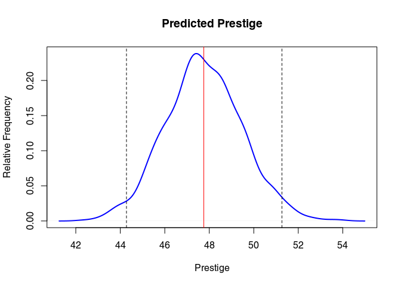

```r
plot(density(predictions), main = "Predicted Prestige", lwd = 2,
  col = "blue", xlab = "Prestige", ylab = "Relative Frequency")
abline(v = EV, col = "red")
abline(v = c(lowerCI, upperCI), lty = 2)
```

Now let’s estimate the distribution of prestige values for a job that is the same in every respect but pays $12,000 #instead of $10,000:

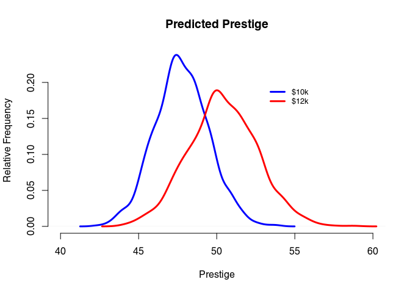

```r
xhyp2 <- c(1, 10, 12000, 50)  # define our scenario vector
predictions2 <- simbetas %*% xhyp2  # multiply by the simulated coefficients
plot(density(predictions), main = "Predicted Prestige", lwd = 3,
  col = "blue", bty = "n", xlab = "Prestige", ylab = "Relative Frequency",
  xlim = c(40, 60))
lines(density(predictions2), lwd = 3, col = "red")
legend(53, 0.2, c("$10k", "$12k"), lwd = 3, col = c("blue", "red"),
  cex = 0.8, bty = "n")
```

**Question:** Why are we using density plots instead of a histogram? **Question:** Why does the $12k distribution have greater variation than the $10k one?  
Hint: look at the mean of the income variable.

## Plotting Expected Values

Suppose we want to examine the effect of changes in income on prestige over a continuous range of values - i.e., not just the $10k and $12k scenarios we looked at above.

Create the range of X for which you want to explore the expectations for y, in a dataframe with placeholders for the results (Note we’re using “length.out” instead of “by” in `seq`):

```r
scenarios <- data_frame(income = seq(from = min(jobs$income),
  to = max(jobs$income), length.out = 10), EVs = NA, lowerCIs = NA,
  upperCIs = NA)
```

Then get the coefficients and vcmatrix from the model:

```r
pe <- coef(foxmodel)
vc <- vcov(foxmodel)
```

Take 1000 draws from the multivariate normal distribution:

```r
simbetas <- mvrnorm(1000, pe, vc)
```

Set up a loop that goes through all 10 values in the income.range vector:

```r
for (i in 1:nrow(scenarios)) {

  # define the covariate values for the current scenario
  xhyp <- c(1, 10, scenarios$income[i], 50)  #make sure you understand what these numbers represent

  # calculate the 1000 predictions:
  yhyp <- simbetas %*% xhyp

  # Now slot the mean, lowerCI and upperCI values into the
  # appropriate positions in the results vectors:
  scenarios$EVs[i] <- mean(yhyp)
  scenarios$lowerCIs[i] <- sort(yhyp)[25]
  scenarios$upperCIs[i] <- sort(yhyp)[975]

}  # close i loop
```

So, now that we’ve got the results, we can look at them :

```r
scenarios
```

```
## Source: local data frame [10 x 4]
##
##       income      EVs lowerCIs upperCIs
## 1    611.000 35.38717 32.41936 38.33361
## 2   3418.556 39.06669 37.06175 41.03758
## 3   6226.111 42.74622 40.62675 44.84447
## 4   9033.667 46.42575 43.32464 49.73534
## 5  11841.222 50.10527 45.66214 54.91945
## 6  14648.778 53.78480 47.82937 60.15889
## 7  17456.333 57.46433 49.98093 65.44252
## 8  20263.889 61.14385 52.22732 70.67837
## 9  23071.444 64.82338 54.43421 75.90819
## 10 25879.000 68.50290 56.58665 81.21066
```

But of course it’s much better to plot them:

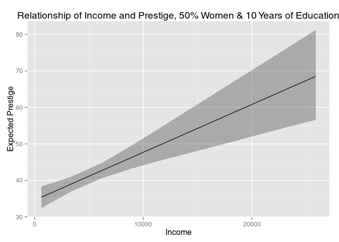

```r
ggplot(scenarios, aes(x = income)) + geom_line(aes(y = EVs)) +
  geom_ribbon(aes(ymin = lowerCIs, ymax = upperCIs), alpha = 1/3) +
  labs(x = "Income", y = "Expected Prestige", title = "Relationship of Income and Prestige, 50% Women & 10 Years of Education")
```

## Illustrating interaction terms with a first differences plot – including confidence intervals!

```r
foxmodel2 <- lm(prestige ~ education + income * women, data = jobs)
summary(foxmodel2)
```

```
##
## Call:
## lm(formula = prestige ~ education + income * women, data = jobs)
##
## Residuals:
##      Min       1Q   Median       3Q      Max
## -19.4623  -5.1970  -0.4228   5.2365  16.8228
##
## Coefficients:
##                Estimate Std. Error t value Pr(>|t|)
## (Intercept)  -3.760e+00  3.698e+00  -1.017    0.312
## education     3.883e+00  4.268e-01   9.098 1.19e-14 ***
## income        1.236e-03  2.793e-04   4.426 2.51e-05 ***
## women        -8.692e-02  5.599e-02  -1.552    0.124
## income:women  2.179e-05  1.318e-05   1.653    0.102
## ---
## Signif. codes:  0 '***' 0.001 '**' 0.01 '*' 0.05 '.' 0.1 ' ' 1
##
## Residual standard error: 7.778 on 97 degrees of freedom
## Multiple R-squared:  0.8037, Adjusted R-squared:  0.7956
## F-statistic: 99.29 on 4 and 97 DF,  p-value: < 2.2e-16
```

What do these results mean? Let’s use first differences

Get the coefficients and vcmatrix from the model:

```r
pe2 <- coef(foxmodel2)
vc2 <- vcov(foxmodel2)
```

Take 1000 draws from the multivariate normal distribution:

```r
simbetas2 <- mvrnorm(1000, pe2, vc2)
```

Set up range of women employed in that occupation, and define the high and low values of income:

```r
women_range <- seq(from = 0, to = 100, by = 10)
income_hi <- mean(jobs$income) + sd(jobs$income)
income_lo <- mean(jobs$income) - sd(jobs$income)
```

Create placeholders for the results:

```r
scenarios_women <- data_frame(women = women_range, fd_mean = NA,
  fd_lowerCI = NA, fd_upperCI = NA)
```

Set up a loop that goes through all 11 values in the women_range vector:

```r
for (i in 1:nrow(scenarios_women)) {

  # define the covariate values for the current scenario
  x.income_hi <- c(1, 10, income_hi, women_range[i], income_hi *
    women_range[i])
  # make sure you understand where these numbers are coming
  # from
  x.income_lo <- c(1, 10, income_lo, women_range[i], income_lo *
    women_range[i])

  firstdifferences <- (simbetas2 %*% x.income_hi) - (simbetas2 %*%
    x.income_lo)
  scenarios_women$fd_mean[i] <- mean(firstdifferences)
  scenarios_women$fd_lowerCI[i] <- quantile(firstdifferences,
    probs = 0.025)
  scenarios_women$fd_upperCI[i] <- quantile(firstdifferences,
    probs = 0.975)  #why these numbers instead of .5 and .95?

}  # close i loop
```

Examine the results in a table:

```r
scenarios_women
```

```
## Source: local data frame [11 x 4]
##
##    women  fd_mean fd_lowerCI fd_upperCI
## 1      0 10.58827   5.759927   15.29969
## 2     10 12.44224   7.266880   16.92148
## 3     20 14.29621   8.297855   19.83057
## 4     30 16.15017   8.668012   23.43796
## 5     40 18.00414   8.739757   27.19075
## 6     50 19.85811   8.727098   31.13583
## 7     60 21.71207   8.758732   34.96862
## 8     70 23.56604   8.788577   38.80756
## 9     80 25.42001   8.631279   42.84399
## 10    90 27.27397   8.560104   47.07923
## 11   100 29.12794   8.449189   51.17903
```

But of course it’s much better to plot them:

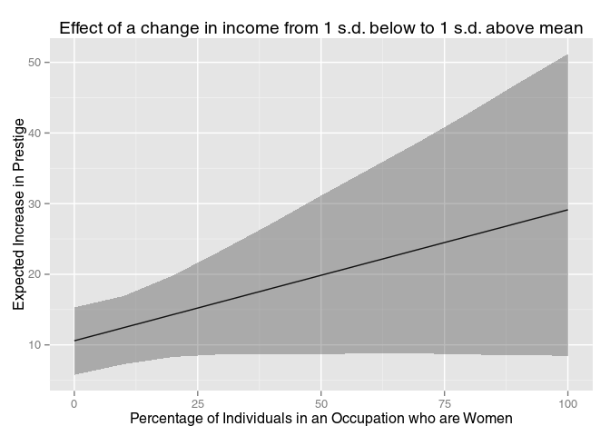

```r
ggplot(scenarios_women, aes(x = women)) + geom_line(aes(y = fd_mean)) +
  geom_ribbon(aes(ymin = fd_lowerCI, ymax = fd_upperCI), alpha = 1/3) +
  labs(x = "Percentage of Individuals in an Occupation who are Women",
    y = "Expected Increase in Prestige", title = "Effect of a change in income from 1 s.d. below to 1 s.d. above mean")
```

*Note: Chris has a package called simcf that does this and integrates well with his package tile for plotting - more detail on this later*

**Challenge**

Return to the first model we ran on the occupational prestige data.

```r
foxmodel <- lm(prestige ~ education + income + women, data = jobs)
summary(foxmodel)
```

```
##
## Call:
## lm(formula = prestige ~ education + income + women, data = jobs)
##
## Residuals:
##      Min       1Q   Median       3Q      Max
## -19.8246  -5.3332  -0.1364   5.1587  17.5045
##
## Coefficients:
##               Estimate Std. Error t value Pr(>|t|)
## (Intercept) -6.7943342  3.2390886  -2.098   0.0385 *
## education    4.1866373  0.3887013  10.771  < 2e-16 ***
## income       0.0013136  0.0002778   4.729 7.58e-06 ***
## women       -0.0089052  0.0304071  -0.293   0.7702
## ---
## Signif. codes:  0 '***' 0.001 '**' 0.01 '*' 0.05 '.' 0.1 ' ' 1
##
## Residual standard error: 7.846 on 98 degrees of freedom
## Multiple R-squared:  0.7982, Adjusted R-squared:  0.792
## F-statistic: 129.2 on 3 and 98 DF,  p-value: < 2.2e-16
```

For each independent variable in the model, calculate the expected change in prestige that results from a change in that independent variable from one SD below its mean to one SD above its mean, along with 95 percent confidence intervals around this quantity.

# Sources

- Oil data from : Ross 2001.
- http://staff.washington.edu/csjohns/503/lab5.r
- http://staff.washington.edu/csjohns/503/lab6.r
- http://staff.washington.edu/csjohns/503/lab7.r

This work is licensed under a [Creative Commons Attribution-NonCommercial-ShareAlike 4.0 International License](http://creativecommons.org/licenses/by-nc-sa/4.0/). R code is licensed under a [BSD 2-clause](http://www.r-project.org/Licenses/BSD_2_clause) license.